# Quanlitative and LDV Models

Hyundo Im

2018 March

## Used libraries

```r
library(nlWaldTest)
library(lmtest)
library(broom)
library(PoEdata)
library(car)
library(sandwich)
library(knitr)
library(forecast)
library(AER)
library(xtable)
library(stargazer)
```

## The Linear Probability Model

Suppose the response variable is binary,

$$\begin{align}
y = 1 \text{if an individual chooses to buy a house}
\\
y = 0 \text{ if an individual chooses not to buy}
\end{align}$$

The linear probability model has the general form of equation below:

$$\begin{align}
y = E(y) + e = \beta_1 + \beta_2x_2 + ... + \beta_kx_k + e
\end{align}$$

## The Probit Model

**Probit model**: It assumes a nonlinear relationship between the response variable and regressors, this relationship seing the cumulative distribution function of the normal distribution

$$\begin{align}
p = P[y=1] = E(y|x) = \Phi(\beta_1 + \beta_2x)
\end{align}$$

The slope of the regression curve is not constant, but is given by the standard normal density function:

$$\begin{align}
\frac{dp}{dx} = \phi(\beta_1 + \beta_2x)\beta_2
\end{align}$$

Predictions of the probability that y = 1 are given by:

$$\begin{align}
\hat{p} = \Phi(\hat{\beta}_1 + \hat{\beta}_2x)
\end{align}$$

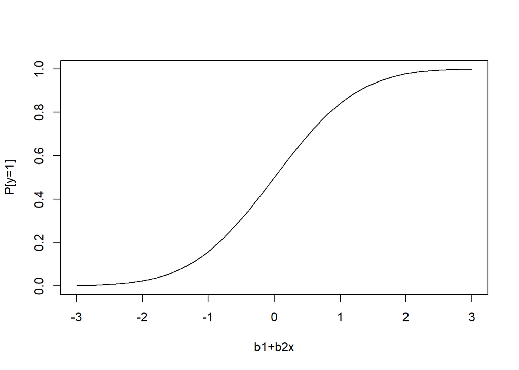

```r
x <- seq(-3,3,.2)
plot(x, pnorm(x), type='l',xlab='b1+b2x', ylab="P[y=1]")
```

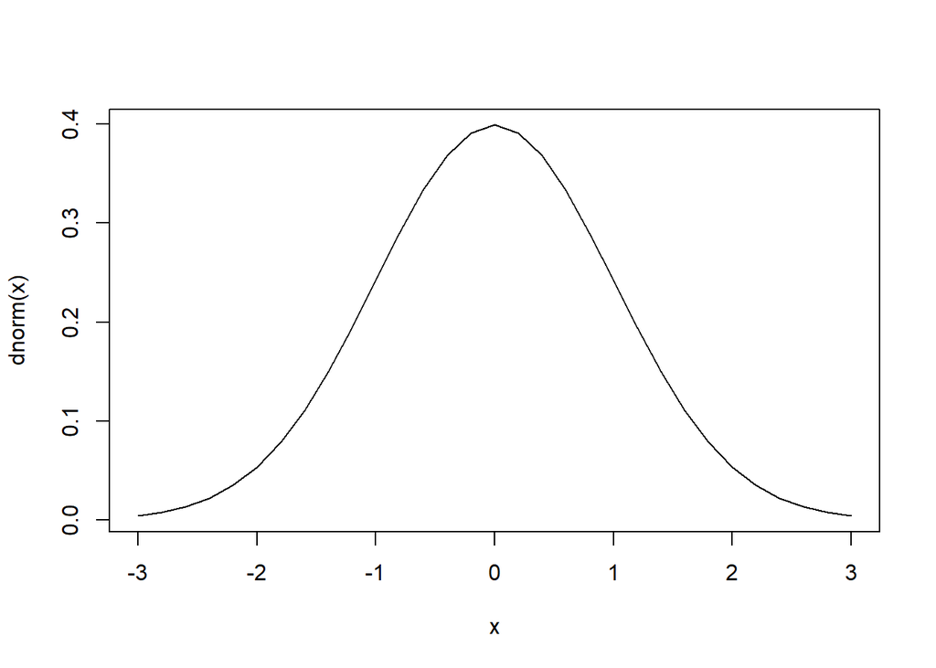

```r
plot(x,dnorm(x),type="l")
```

## The Transportation Example

```r
data("transport")
auto.probit <- glm(auto~dtime, family=binomial(link="probit"),
                   data=transport)
kable(tidy(auto.probit),digits = 4,align = "c",caption =
        "Transport example, estimated by probit")
```

Transport example, estimated by probit

| term | estimate | std.error | statistic | p.value |
| --- | --- | --- | --- | --- |
| (Intercept) | -0.0644 | 0.4007 | -0.1608 | 0.8722 |
| dtime | 0.3000 | 0.1029 | 2.9154 | 0.0036 |

The equation can be used to calculate partial effects of an increase in *dtime* by one unit (10 minutes):

```r
xdtime <- data.frame(dtime=2)
predLinear <- predict(auto.probit,xdtime,
                      data=transport, type="link")
DpDdtime <- coef(auto.probit)[[2]]*dnorm(predLinear)
DpDdtime
```

```
##         1
## 0.1036899
```

The function `predict` has the following general form: `predict(object, newdata=NULL, type=c("link","response","terms"),sefit=FALSE,dispersion=NULL,terms=NULL,na.action=na.pass...)`

The option argument `newdata` must be a data frame containing the new values of the regressors for which the prediction is desired.

```r
xdtime <- data.frame(dtime=3)
predProbit <- predict(auto.probit,xdtime,
                      data=transport, type="response")
predProbit
```

```
##         1
## 0.7982915
```

The marginal effect at the average predicted value can be deterined as follows:

```r
avgPredLinear <- predict(auto.probit, type = "link")
avgPred <- mean(dnorm(avgPredLinear))
AME <- avgPred * coef(auto.probit)
AME
```

```
## (Intercept)       dtime
## -0.01039727  0.04840695
```

## The Logit Model for Binary Choice

Below equations define expressions of the logit model (The two expressions are equivalent)

$$\begin{align}
p = \Lambda(\beta_1 + \beta_2x) = \frac{1}{1+e^{-\beta_1+\beta_2x}}
\\
p = \frac{exp(\beta_1 + \beta_2x)}{1+exp(\beta_1+\beta_2x)}
\end{align}$$
Following equation gives the marginal effect of a change in the regressor $x_k$ on the probability that y = 1
$$\begin{align}
\frac{\partial p}{\partial x_k} = \beta_k\Lambda(1-\Lambda)
\end{align}$$

```r
data("coke")
coke.logit <- glm(coke~pratio + disp_coke + disp_pepsi,
                  data=coke, family=binomial(link="logit"))
kable(tidy(coke.logit), digits = 5,align = "c",
      caption = "Logit estimates for the 'coke' dataset")
```

Logit estimates for the ‘coke’ dataset

| term | estimate | std.error | statistic | p.value |
| --- | --- | --- | --- | --- |
| (Intercept) | 1.92297 | 0.32582 | 5.90200 | 0.00000 |
| pratio | -1.99574 | 0.31457 | -6.34437 | 0.00000 |
| disp_coke | 0.35160 | 0.15853 | 2.21781 | 0.02657 |
| disp_pepsi | -0.73099 | 0.16783 | -4.35551 | 0.00001 |

```r
coke.LPM <- lm(coke~pratio + disp_coke + disp_pepsi,
               data=coke)
coke.probit <- glm(coke~pratio + disp_coke + disp_pepsi,
                   data=coke,family = binomial(link="probit"))
stargazer(coke.LPM,coke.probit,coke.logit,
                     header=FALSE,
                     title="Three binary choice models for the 'coke' dataset",
          type="text",
                     keep.stat = "n",digits=4,
                     single.row = FALSE,
                     intercept.bottom = FALSE,
                     model.names = FALSE,
                     column.labels = c("LPM","probit","logit"))
```

```
##
## Three binary choice models for the 'coke' dataset
## =============================================
##                    Dependent variable:
##              --------------------------------
##                            coke
##                 LPM       probit     logit
##                 (1)        (2)        (3)
## ---------------------------------------------
## Constant     0.8902***  1.1080***  1.9230***
##               (0.0655)   (0.1925)   (0.3258)
##
## pratio       -0.4009*** -1.1459*** -1.9957***
##               (0.0613)   (0.1839)   (0.3146)
##
## disp_coke     0.0772**   0.2172**   0.3516**
##               (0.0344)   (0.0962)   (0.1585)
##
## disp_pepsi   -0.1657*** -0.4473*** -0.7310***
##               (0.0356)   (0.1010)   (0.1678)
##
## ---------------------------------------------
## Observations   1,140      1,140      1,140
## =============================================
## Note:             *p<0.1; **p<0.05; ***p<0.01
```

**Three binary choice models for the ‘coke’ dataset**

|  | *Dependent variable:* |  |  |
| --- | --- | --- | --- |
|  | coke |  |  |
|  | LPM | probit | logit |
|  | (1) | (2) | (3) |
| Constant | 0.8902*** | 1.1080*** | 1.9230*** |
|  | (0.0655) | (0.1925) | (0.3258) |
| pratio | -0.4009*** | -1.1459*** | -1.9957*** |
|  | (0.0613) | (0.1839) | (0.3146) |
| disp_coke | 0.0772** | 0.2172** | 0.3516** |
|  | (0.0344) | (0.0962) | (0.1585) |
| disp_pepsi | -0.1657*** | -0.4473*** | -0.7310*** |
|  | (0.0356) | (0.1010) | (0.1678) |
| Observations | 1,140 | 1,140 | 1,140 |
| *Note:* | p<0.1; p<0.05; p<0.01 |  |  |

## Logit Model (Cont’d)

Prediction and marginal effects for the *logit* model can be determined using the same `predict` function:

```r
tble <- data.frame(table(true=coke$coke,
                         predicted=round(fitted(coke.logit))))
kable(tble,align = 'c', caption = "Logit prediction results")
```

Logit prediction results

| true | predicted | Freq |
| --- | --- | --- |
| 0 | 0 | 507 |
| 1 | 0 | 263 |
| 0 | 1 | 123 |
| 1 | 1 | 247 |

```r
Hnull <- "disp_coke+disp_pepsi=0"
linearHypothesis(coke.logit,Hnull)
```

```
## Linear hypothesis test
##
## Hypothesis:
## disp_coke  + disp_pepsi = 0
##
## Model 1: restricted model
## Model 2: coke ~ pratio + disp_coke + disp_pepsi
##
##   Res.Df Df  Chisq Pr(>Chisq)
## 1   1137
## 2   1136  1 5.6105    0.01785 *
## ---
## Signif. codes:  0 '***' 0.001 '**' 0.01 '*' 0.05 '.' 0.1 ' ' 1
```

The above code tests the hypothesis that the effects of displaying coke and displaying pepsi have equal but opposite effects, a null hypothesis that is being rejected by the test.

Following test examines the null hypothesis that displaying coke and pepsi have (jointly) no effect on an individual’s choice.

```r
Hnull <- c("disp_coke=0","disp_pepsi=0")
linearHypothesis(coke.logit,Hnull)
```

```
## Linear hypothesis test
##
## Hypothesis:
## disp_coke = 0
## disp_pepsi = 0
##
## Model 1: restricted model
## Model 2: coke ~ pratio + disp_coke + disp_pepsi
##
##   Res.Df Df  Chisq Pr(>Chisq)
## 1   1138
## 2   1136  2 18.973  7.586e-05 ***
## ---
## Signif. codes:  0 '***' 0.001 '**' 0.01 '*' 0.05 '.' 0.1 ' ' 1
```

## Multinomial Logit

For multinomial logit, we use a package `nnet`. From `nnet` package, we will use `multinom` function The respons variables are: * *psechoice* = 1 no college, * *psechoice* = 2 two year college, * *psechoice* = 3 four year college

```r
library(nnet)
data("nels_small")
nels.multinom <- multinom(psechoice~grades, data=nels_small)
summary(nels.multinom)
```

```
## Call:
## multinom(formula = psechoice ~ grades, data = nels_small)
##
## Coefficients:
##   (Intercept)     grades
## 2    2.505273 -0.3086404
## 3    5.770170 -0.7062468
##
## Std. Errors:
##   (Intercept)     grades
## 2   0.4183944 0.05228532
## 3   0.4043290 0.05292638
##
## Residual Deviance: 1750.626
## AIC: 1758.626
```

`multinom()` function will return coefficient estimates for each level of the response variable *psechoice*, except for the first level, which is the benchmark.

```r
medGrades <- median(nels_small$grades)
fifthPercentileGrades <- quantile(nels_small$grades,.05)
newdat <- data.frame(grades = c(medGrades,fifthPercentileGrades))
pred <- predict(nels.multinom,newdat,"probs")
pred
```

```
##             1          2         3
##    0.18101808 0.28557312 0.5334088
## 5% 0.01781764 0.09662199 0.8855604
```

The above code shows how the usual function `predict` can calculate the predicted probabilities of choosing any of three secondary education levels for two arbitrary grades: one at the median grade in the sample, and the other at the top fifth percent.